# Praca domowa 1

Paulina Kostrzewa

8 października 2016

Praca domowa dotyczyła znaleźnienia przykładu źle zobrazowanych danych na podstawie artykułów w Internecie. Następnie należało zaproponować własny sposób przedstawienia tych danych.

Znaleziony przeze mnie artykuł, znajduje się pod poniższym linkiem: http://www.bankier.pl/wiadomosc/Raport-o-cenach-wynajmu-pazdziernik-2016-7480186.html

Jest to raport cen wynajmu mieszkań przedstawiony za pomocą tabeli, w której widnieje podział na miasta, metraż mieszkania i trzy różne momenty, w czasie których porównywano ceny wynajmu mieszkań. Znajduje się tam również wyliczony procent z jakim cena wynajmu mieszkania zmieniła się w stosunku do poprzedniego miesiąca (lipiec i sierpień 2016) oraz w stosunku do poprzedniego roku (2015 i 2016).

Tabela zawiera bardzo dużo informacji. Poniżej znajduje się kilka początkowych wierszy z tabeli:

```
##      Miasto Metraz X2015.08.15 X2016.07.16 X2016.08.16 średnia_cena_2016
## 1 Bydgoszcz   maly         939        1032        1065          1012.000
## 2 Bydgoszcz sredni        1234        1347        1370          1317.000
## 3 Bydgoszcz   duzy        1679        1863        1880          1807.333
## 4    Gdansk   maly        1356        1586        1512          1484.667
## 5    Gdansk sredni        1948        2247        2267          2154.000
## 6    Gdansk   duzy        2754        2972        2986          2904.000
##   Zmiana.mdm Zmiana.rdr
## 1         3%        13%
## 2         2%        11%
## 3         1%        12%
## 4        -5%        12%
## 5         1%        16%
## 6         0%         8%
```

Jednak, aby zauważyć zależności dużo lepiej sprawdza się wykres, na którym łatwo porównać, w którym mieście najlepiej opłacałoby się wynająć interesujące nas mieszkanie.

Do odczytania rozwiązania potrzeba jest zainstalowana biblioteka ggplot2. Poniżej znajduje się kod, który tworzy wykres:

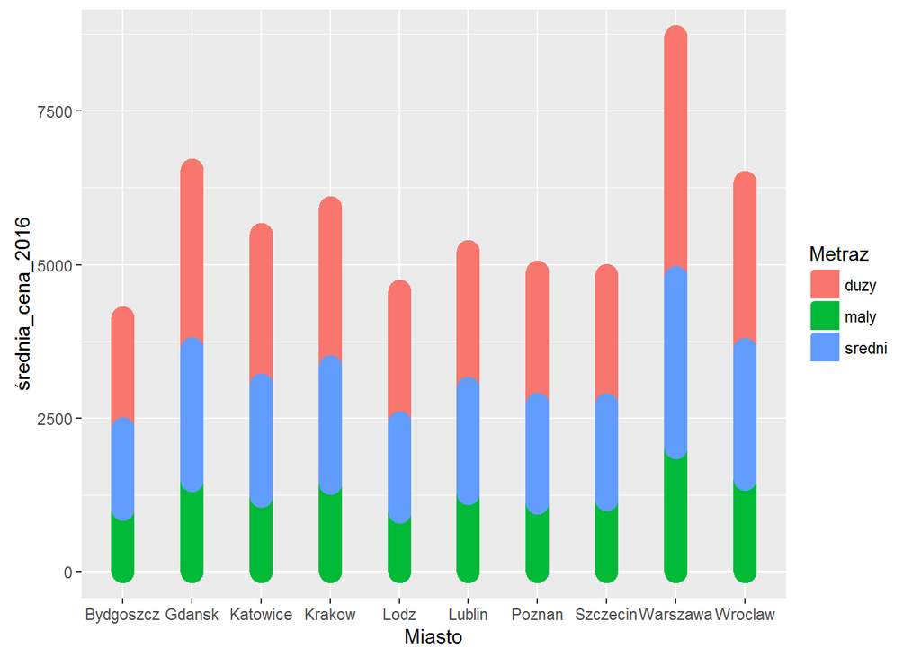

```r
tabela<-read.csv(file="C:\\Users\\kp\\Desktop\\Techniki wizualizacji danych\\cenynieruch.csv", sep=';', dec=',')

ggplot(tabela, aes(x=Miasto, y=średnia_cena_2016,color=Metraz))+
   geom_area(aes(fill = Metraz), size=6)
```

Z wykresu łatwo zauważyć, że cena za wynajem najmniejszej opcji metrażowej jest najtańsza w Łodzi, Bydgoszczy i Poznaniu, a najdroższa w Warszawie. Co do średniej wielkości metrażu, najtaniej jest w Bydgoszczy i Łodzi, a najdrożej w Warszawie. Natomiast wynajem mieszkania o dużym metrażu jest najtańszy w Bydgoszczy, a najdroższy znowu w Warszawie. Podsumowując najtansze wynajmy mieszkań są w Bydgoszczy, Łodzi, a najdroższe w Warszawie.

W celu uzyskania dokładnych porównań można teraz posłużyć się tabelą.